# Experiment 2

```python
import scipy
import scipy.io
import numpy as np
import matplotlib.pyplot as plt
```

```python
# Load data
EEG_before = scipy.io.loadmat('EEG_av.mat')
EEG_during = scipy.io.loadmat('EEG_pe.mat')
EEG_after = scipy.io.loadmat('EEG_ap.mat')

EEG_before = EEG_before['EEG_before']
EEG_during = EEG_during['EEG_during']
EEG_after = EEG_after['EEG_after']

# Set sampling frequency variable
fs = 512
```

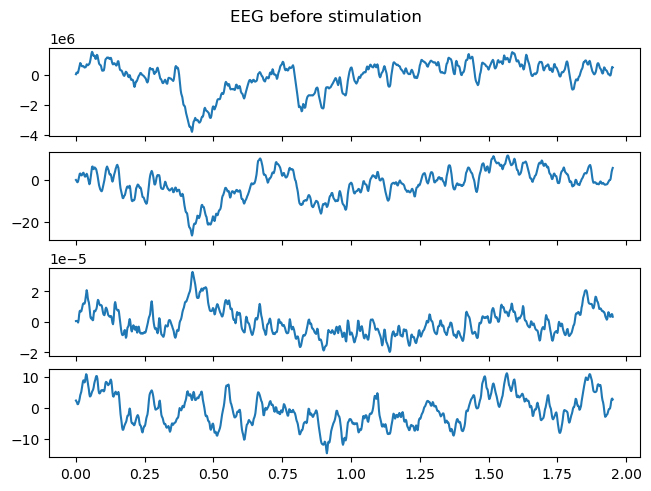

```python
# Plot 4 EEG leads before stimulation
fig, axes = plt.subplots(
    4, 1, sharex='all', constrained_layout=True)
plt.suptitle('EEG before stimulation')
time = np.arange(0, len(EEG_before)/fs, 1/fs)
for i in np.arange(4):
    axes[i].plot(time, EEG_before[:, i])
```

```python
# Perform SVD
Ub, Sb, Vb = np.linalg.svd(EEG_before)
Ud, Sd, Vd = np.linalg.svd(EEG_during)
Ua, Sa, Va = np.linalg.svd(EEG_after)

# Print singular values
Before = 'Singular values before: {:.2f}, {:.2f}, {:.2f}, {:.2f}'
print(Before.format(Sb[0]/max(Sb), Sb[1]/max(Sb), Sb[2]/max(Sb), Sb[3]/max(Sb)))
Before = 'Singular values during: {:.2f}, {:.2f}, {:.2f}, {:.2f}'
print(Before.format(Sd[0]/max(Sd), Sd[1]/max(Sd), Sd[2]/max(Sd), Sd[3]/max(Sd)))
Before = 'Singular values after: {:.2f}, {:.2f}, {:.2f}, {:.2f}'
print(Before.format(Sa[0]/max(Sa), Sa[1]/max(Sa), Sa[2]/max(Sa), Sa[3]/max(Sa)))
```

```
Singular values before: 1.00, 0.00, 0.00, 0.00
Singular values during: 1.00, 0.10, 0.07, 0.07
Singular values after: 1.00, 0.21, 0.19, 0.09
```

```python
# Implement here the pre-processing of the signals
EEG_before = scipy.stats.zscore(EEG_before)
EEG_during = scipy.stats.zscore(EEG_during)
EEG_after= scipy.stats.zscore(EEG_after)
```

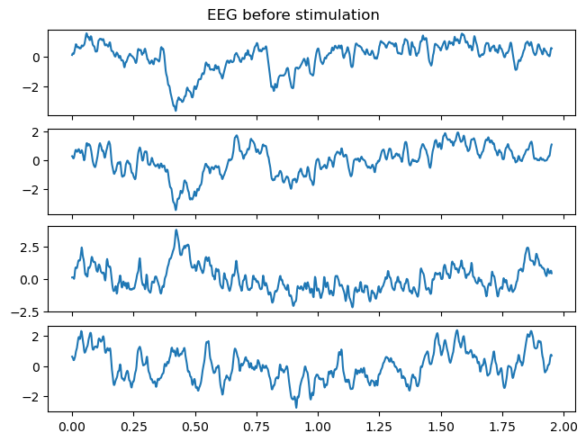

```python
# Plot 4 EEG leads before stimulation after pre-processing
fig, axes = plt.subplots(
    4, 1, sharex='all', constrained_layout=True)
plt.suptitle('EEG before stimulation')
time = np.arange(0, len(EEG_before)/fs, 1/fs)
for i in np.arange(4):
    axes[i].plot(time, EEG_before[:, i])
```

```python
# Perform here the svd
Ub, Sb, Vb = np.linalg.svd(EEG_before)

# Print singular values divided by max value
Before = 'Singular values before stimulation: {:.5f}, {:.5f}, {:.5f}, {:.5f}'
print(Before.format(Sb[0]/max(Sb), Sb[1]/max(Sb), Sb[2]/max(Sb), Sb[3]/max(Sb)))
```

```
Singular values before stimulation: 1.00000, 0.82741, 0.27099, 0.23259
```

```python
# Implement here the pre-processing of the signals during and after stimulation
```

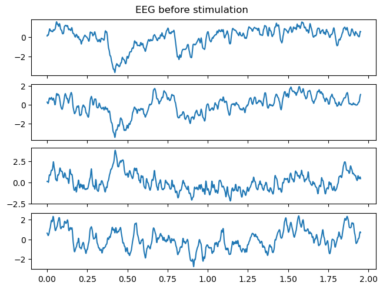

```python
# Plot 4 EEG leads before stimulation
fig, axes = plt.subplots(
    4, 1, sharex='all', constrained_layout=True)
plt.suptitle('EEG before stimulation')
time = np.arange(0, len(EEG_before)/fs, 1/fs)
for i in np.arange(4):
    axes[i].plot(time, EEG_before[:, i])
```

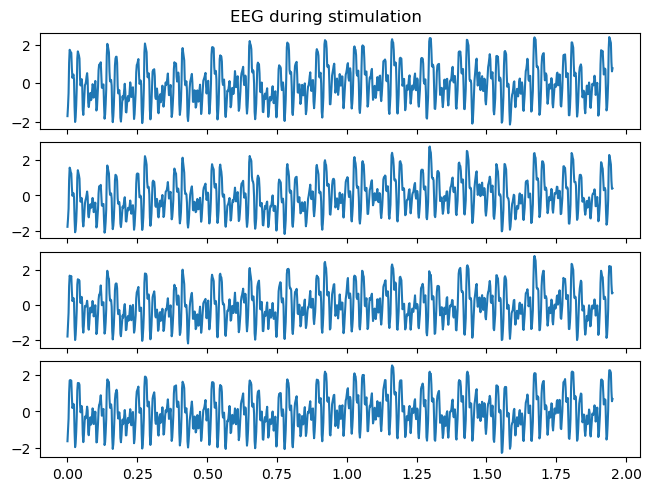

```python
# Plot 4 EEG leads during stimulation
fig, axes = plt.subplots(
    4, 1, sharex='all', constrained_layout=True)
plt.suptitle('EEG during stimulation')
time = np.arange(0, len(EEG_during)/fs, 1/fs)
for i in np.arange(4):
    axes[i].plot(time, EEG_during[:, i])
```

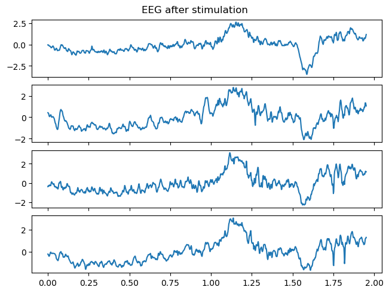

```python
# Plot 4 EEG leads after stimulation
fig, axes = plt.subplots(
    4, 1, sharex='all', constrained_layout=True)
plt.suptitle('EEG after stimulation')
time = np.arange(0, len(EEG_after)/fs, 1/fs)
for i in np.arange(4):
    axes[i].plot(time, EEG_after[:, i])
```

```python
Ub, Sb, Vb = np.linalg.svd(EEG_before)
Ud, Sd, Vd = np.linalg.svd(EEG_during)
Ua, Sa, Va = np.linalg.svd(EEG_after)
# Print singular values
Before = 'Singular values before: {:.2f}, {:.2f}, {:.2f}, {:.2f}'
print(Before.format(Sb[0]/max(Sb), Sb[1]/max(Sb), Sb[2]/max(Sb), Sb[3]/max(Sb)))
Before = 'Singular values during: {:.2f}, {:.2f}, {:.2f}, {:.2f}'
print(Before.format(Sd[0]/max(Sd), Sd[1]/max(Sd), Sd[2]/max(Sd), Sd[3]/max(Sd)))
Before = 'Singular values after: {:.2f}, {:.2f}, {:.2f}, {:.2f}'
print(Before.format(Sa[0]/max(Sa), Sa[1]/max(Sa), Sa[2]/max(Sa), Sa[3]/max(Sa)))
```

```
Singular values before: 1.00, 0.83, 0.27, 0.23
Singular values during: 1.00, 0.10, 0.08, 0.07
Singular values after: 1.00, 0.21, 0.17, 0.10
```

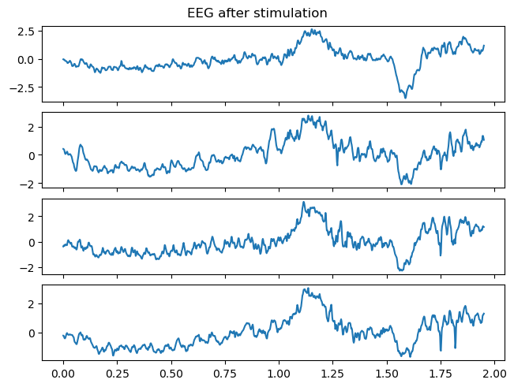

```python
# Plot 4 EEG leads after stimulation
fig, axes = plt.subplots(
    4, 1, sharex='all', constrained_layout=True)
plt.suptitle('EEG after stimulation')
time = np.arange(0, len(EEG_after)/fs, 1/fs)
for i in np.arange(4):
    axes[i].plot(time, EEG_after[:, i])
```

# QUESTION #2.1: Data pre-processing

a) Explain from the singular values of the SVD of the raw EEG signal, the relationship between EEG leads before stimulation.

In the raw signal, we can see that only the first lead seem to contain all the relevant information, which means that the three other are highly correlated to it (=> similar). So, according to this result, the chosen rank would be of 1.

b) Implement pre-processing of the EEG signals before stimulation to normalize the data. Then re-compute the singular value decomposition of the pre-processed signals.

c) Explain the relationship between EEG leads based on these new singular values, and the difference observed with the ones computed in a).

The function scipy.stats.zscore() returns the z-score of each sample value, using the sample mean and standard deviation. The mean values are subtracted to remove the influence of columns common factor on singular values. Then, values are scaled to a variance of one (normalization), which cancels the influence of the differences of amplitude in the signals.  
The singular values obtained are bigger than the ones computed in a) (all above 0.2). This means that all lead signals contain relevant information and that they are not similar to each other (=>independent).

# QUESTION #2.2 : Correlation interpretation

a) Deduce from the resulting singular values the signals are much more correlated during stimulation?

As the three last singular values of the SVD of the pre-processed EEG signal are smaller than before or after stimulation (and also are really small compared to the maximum singular value), we can deduce that the signals are more correlated during stimulation (effective rank of the matrix should be 1 during stimulation).

b) Explain in terms of correlation the difference between each case ( ‘before’, ‘during’, ‘after’), and that ̋after ̋ is between ̋before ̋ and ̋during ̋, which suggests a remanence effect in the stimulation

Before the stimulation, the different lead signals are not correlated with each other that much (high singular values of SVD). During the stimulation, as explained above, the signals are highly correlated with each other (low three last singular values of SVD). The three last singular value of SVD after the simulation are in between those two cases, which could be due to persistence of the stimulation effect (the signals keep a higher level of correlation after stimulation than before).